# Visualizing mathematical models

### 3.3 Visualization of fitness relationship with host exploitation severity

We will visualize the single-strain fitness model

$$w(z;\alpha) = z(1-\alpha z),$$

where:

- $z$ is host exploitation severity (the model’s adjustable trait variable),
- $\alpha$ is a fixed scaling parameter that determines how strongly exploitation reduces transmission opportunity,
- $w$ is parasite fitness (new infected hosts per infected host under the model).

In Julia, we can generate a set of $z$ values, evaluate $w(z;\alpha)$, and plot $w$ versus $z$ for one or several choices of $\alpha$. These values can be generated *systematically*, following some scheme or algorithm, or *stochistically*, such as by sampling from a probability distribution or model. Here, we use methods of the `range` function to generate the sets of values systematically at regular intervals such that they form a “grid” spanning the range of values of interest.

When we plot $w$ versus $z$ for a fixed $\alpha$, we typically restrict $z$ to

$$0 \le z \le \frac{1}{\alpha},$$

so that the transmission-opportunity term $(1-\alpha z)$ stays nonnegative.

### 3.4 Single $\alpha$, implicit plot (quick exploratory)

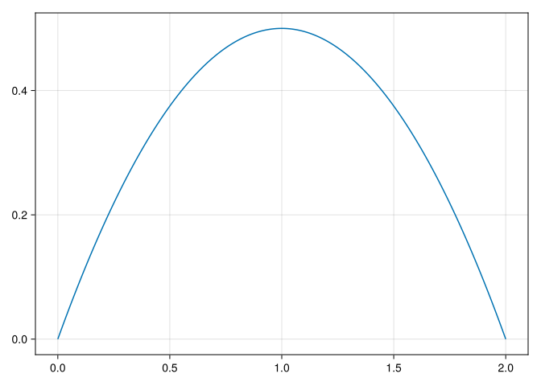

```julia
using CairoMakie

# Fitness model
w(z, α) = z * (1 - α*z)

# Choose a single α value
α = 0.5

# Generate z-values over the biologically meaningful range
z_vals = range(0.0, 1/α; length = 400)

# Evaluate the model on the sequence
w_vals = map(z -> w(z, α), z_vals)

# Quick plot with implicit Figure/Axis
lines(z_vals, w_vals)
```

This produces one curve showing how fitness changes as host exploitation severity $z$ increases, holding $\alpha$ fixed.

Multiple $\alpha$ values on the same plot (explicit Figure and Axis) using CairoMakie

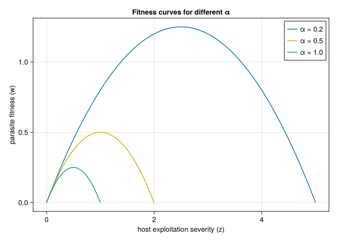

```julia
# Fitness model
w(z, α) = z * (1 - α*z)

# Choose several α values to compare
α_values = [0.2, 0.5, 1.0]

# Create Figure and Axis explicitly
fig = Figure()
ax = Axis(
    fig[1, 1],
    xlabel = "host exploitation severity (z)",
    ylabel = "parasite fitness (w)",
    title  = "Fitness curves for different α"
)

# Add one curve per α onto the same axis
for α in α_values
    z_vals = range(0.0, 1/α; length = 400)
    w_vals = map(z -> w(z, α), z_vals)
    lines!(ax, z_vals, w_vals, label = "α = $(α)")
end

# Add a legend
axislegend(ax)

fig
```

Here, $\alpha$ plays the role of a parameter you “sweep” across several values, to see how the $w$–$z$ relationship changes.

Surface plot: fitness as a function of $z$ and $\alpha$

To visualize the full two-parameter relationship $w(z;\alpha)$, we evaluate $w$ on a 2D “grid” of $(z,\alpha)$ values and plot a surface.

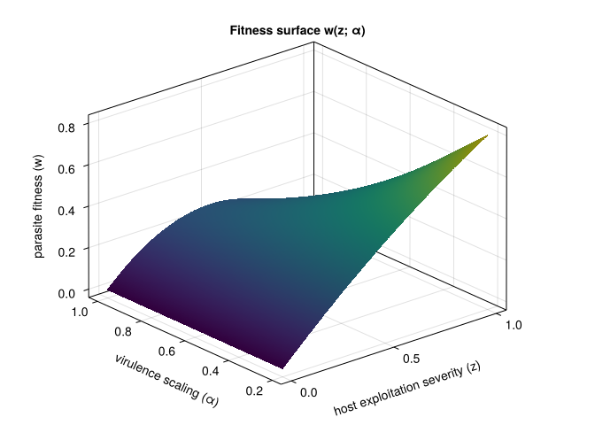

```julia
using CairoMakie

# Fitness model
w(z, α) = z * (1 - α*z)

# Grid of α values (parameter axis)
α_vals = range(0.2, 1.0; length = 120)

# Grid of z values (trait axis)
# Use a common z-range for the surface; choose up to 1/max(α) so the full grid is comparable
z_max = 1 / maximum(α_vals)
z_vals = range(0.0, z_max; length = 200)

# Evaluate w on the (z, α) grid:
# W[i, j] = w(z_vals[i], α_vals[j])
W = [w(z, α) for z in z_vals, α in α_vals]

# Plot as a 3D surface
fig = Figure()
ax3 = Axis3(
    fig[1, 1],
    xlabel = "host exploitation severity (z)",
    ylabel = "virulence scaling (α)",
    zlabel = "parasite fitness (w)",
    title  = "Fitness surface w(z; α)"
)

surface!(ax3, z_vals, α_vals, W)

fig
```

This surface makes it visually explicit that $w$ depends on both the trait value ($z$) and the environment/biology scaling parameter ($\alpha$).

**Exercise 3**

Single-curve practice (implicit plot)

Set $\alpha = 0.25$ and reproduce the single-curve plot.

Increase the resolution by changing length = 400 to length = 2000.

Restrict the plotted domain to $0 \le z \le \frac{1}{2\alpha}$ and compare the shape to the full range $0 \le z \le \frac{1}{\alpha}$.

**Exercise 4**

Multiple-curve practice (explicit Axis, adding curves)

Plot curves for $\alpha \in {0.1, 0.2, 0.4, 0.8}$ on the same axis.

Add a second axis below the first that plots the same curves using scatter! instead of lines!.

Change axis labels and title so that the plot reads well when exported.

**Exercise 5**

Surface practice (2D grid evaluation)

Change the $\alpha$ grid to range(0.1, 2.0; length = 200) and regenerate the surface.

Replace the surface with a heatmap of $w$ over $(z,\alpha)$ using heatmap!(…).

Modify the grid so that, for each $\alpha$, you only include $z \le 1/\alpha$ (the nonnegative-opportunity region) by setting $w(z,\alpha) = NaN$ whenever $z > 1/\alpha$, and observe how the plotted region changes.

Back to top

## References

Frank, Steven A. 1996. “Models of Parasite Virulence.” *The Quarterly Review of Biology* 71 (1): 37–78. https://doi.org/10.1086/419267.